# ACA 4

Cameron Diwa

11/30/2021

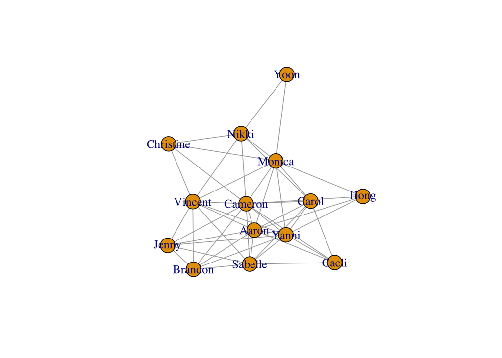

```r
plot(berkz_matrix)
```

```r
degree(berkz_matrix) # counts the number of edges for each node
```

```
##   Cameron   Vincent     Yanni     Aaron   Brandon     Carol     Caeli    Monica
##        12         9        10        10         6         7         5         9
## Christine     Nikki      Yoon      Hong   Sabelle     Jenny
##         4         6         2         4         8         6
```

```r
betweenness(berkz_matrix, normalized = TRUE) # measures how quickly a node can travel to the rest of the graph
```

```
##    Cameron    Vincent      Yanni      Aaron    Brandon      Carol      Caeli
## 0.15747863 0.07200855 0.06185897 0.06185897 0.00000000 0.03034188 0.00000000
##     Monica  Christine      Nikki       Yoon       Hong    Sabelle      Jenny
## 0.13835470 0.00000000 0.04967949 0.00000000 0.00000000 0.01816239 0.00000000
```

```r
betweenness(berkz_matrix, directed = FALSE, normalized = TRUE) # detects the amount of influence a node has over the flow of information in a graph
```

```
##    Cameron    Vincent      Yanni      Aaron    Brandon      Carol      Caeli
## 0.15747863 0.07200855 0.06185897 0.06185897 0.00000000 0.03034188 0.00000000
##     Monica  Christine      Nikki       Yoon       Hong    Sabelle      Jenny
## 0.13835470 0.00000000 0.04967949 0.00000000 0.00000000 0.01816239 0.00000000
```

```r
fg <- cluster_fast_greedy(berkz_matrix) # detects communities within the network
membership(fg) # shows who is in which community
```

```
##   Cameron   Vincent     Yanni     Aaron   Brandon     Carol     Caeli    Monica
##         1         2         1         1         1         1         1         2
## Christine     Nikki      Yoon      Hong   Sabelle     Jenny
##         2         2         2         1         1         1
```

```r
sizes(fg)
```

```
## Community sizes
## 1 2
## 9 5
```

I chose a social network I was a part of at my undergraduate school. Each node represents a person I formed a friendship with at some point during that time. Each edge represents a friendship/connection that has lasted for a year or longer.

First, I created the dataset as an adjacent matrix, where 1 represents an existing friendship/connection, and 0 represents no friendship/connection. The degree centrality ranges from 2 to 12, where Yoon has the least number of edges (and therefore the least connections in this social network) and I have the most. The betweenness centrality computation shows that I have the most influence, and Brandon, Caeli, Christine, Yoon, Hong, and Jenny have no influence.

Two communities were detected. One community is comprised of Yanni, Aaron, Brandon, Carol, Caeli, Hong, Sabelle, Jenny, and I. The other community is comprised of Vincent, Monica, Christine, Nikki, and Yoon. I am unsure how these communities were detected. Based on my knowledge of each person’s connections with the other people in the network, I anticipated that Vincent, Yanni, Aaron, Brandon, Carol, Caeli, Monica, Sabelle, Jenny, and I would be in one community, and the rest in another community.

Overall, the visualization of the network is accurate, where people with more connections are closer to the center, and people with less connections are in the outer areas.